This tutorial is part of [viskex](http://viskex.github.io/).

[figure not shown]

# Customizing the pyvista backend when running in jupyter notebooks

```python
import os
```

```python
import firedrake
import pyvista
```

```python
import viskex
```

Generate a mesh of the unit square by dividing each edge of the square in 6 segments.

```python
square = firedrake.UnitSquareMesh(6, 6, distribution_parameters={"partitioner_type": "simple"})
```

The interactive plots rendered in jupyter notebooks are prepared by `trame`, which is integrated in `pyvista`. The available backends are:

- the `client` backend (interactive), which renders the scene on the client side using `vtk.js`,
- the `server` backend (interactive), which runs a VTK render window on the server and sends back a compressed image,
- the `html` backend (partially interactive), which generates a static HTML representation of the scene,
- the `trame` backend (interactive or partially interactive), a default among `client`, `server` and `html`,
- the `static` backend (not interactive), a static image of the scene.

`viskex` automatically chooses the default backend as follows:

- if an environment variable `VISKEX_PYVISTA_BACKEND` is provided, then the default client is its value; otherwise
- if running on Google Colab or on Kaggle, the default client is `html`, as the other backends are not functional there; otherwise
- if running elsewhere, the default backend is `client`.

The simplest way to set the plotting backend is by setting the variable `VISKEX_PYVISTA_BACKEND` in the environment before running the notebook. The chosen backend will be used in every plot.

If a more fine grained control is needed (e.g., setting a different backend for each plot), users can change the backend in one of the following ways:

1. Use the lower level `viskex.FiredrakePlotter` class instead of the `viskex.firedrake` functions. The functions in the `viskex.firedrake` module delegate the preparation of the `pyvista` plotter to the `viskex.FiredrakePlotter` class, and then automatically call `.show()` on the prepared `pyvista` plotter. Instead, by using the lower level class the `jupyter_backend` can be passed as keyword argument to the `pyvista` plotter. The choice of the backend will only be applied to the current plot.

```python
if os.environ.get("GITHUB_ACTIONS", "") != "true":  # do not open render window on CI or on website
    plotter_client = viskex.FiredrakePlotter.plot_mesh(square)
    plotter_client.show(jupyter_backend="client")
```

```python
plotter_html = viskex.FiredrakePlotter.plot_mesh(square)
plotter_html.show(jupyter_backend="html")
```

```
2026-10-05 10:42:53.174 (   1.157s) [    7FC3FF527080]vtkXOpenGLRenderWindow.:1452  WARN| bad X server connection. DISPLAY=
```

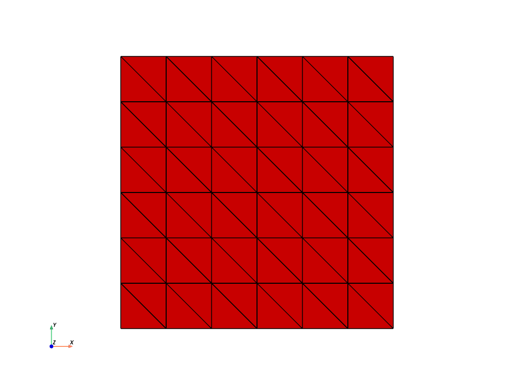

```python
plotter_static = viskex.FiredrakePlotter.plot_mesh(square)
plotter_static.show(jupyter_backend="static")
```

2. Overwrite the `jupyter_backend` in `pyvista`'s global theme. The typical suggested workflow however would be to simply use the `VISKEX_PYVISTA_BACKEND` environment variable, which sets that same theme option.

```python
backup_jupyter_backend = pyvista.global_theme.jupyter_backend
```

```python
if os.environ.get("GITHUB_ACTIONS", "") != "true":  # do not open render window on CI or on website
    pyvista.global_theme.jupyter_backend = "client"
    viskex.firedrake.plot_mesh(square)
```

```python
pyvista.global_theme.jupyter_backend = "html"
viskex.firedrake.plot_mesh(square)
```

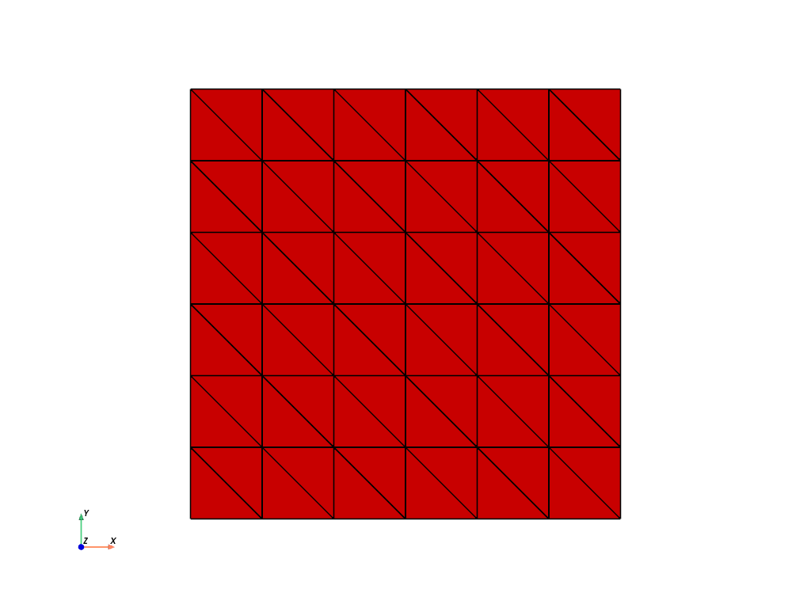

```python
pyvista.global_theme.jupyter_backend = "static"
viskex.firedrake.plot_mesh(square)
```

```python
pyvista.global_theme.jupyter_backend = backup_jupyter_backend
```

### What's next?

- repeat this step with dolfinx